# New SLiM model - write-up

Isabel Kim 6/7/2022

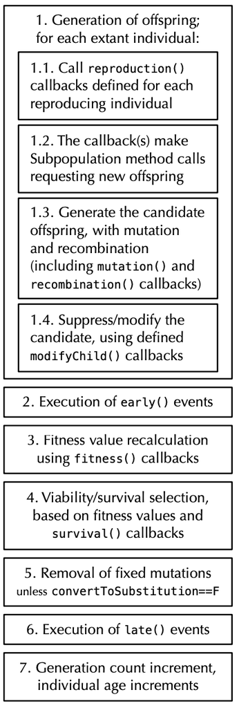

```r
knitr::include_graphics("../slim/order-slim.png")
```

## Generation `10() late` drive drop

- At position 0.5 (the midpoint), add `DRIVE_DROP_SIZE` number of drive homozygotes.
- Write output out to console
- Let everyone (drives *and* wild-types) disperse according to the Gaussian dispersal kernel with mean 0 and standard deviation `sigma`
  - This means that the diffusion constant, `D`, equals `(1/2)(sigma^2)`
- Evaluate the interactions

## `reproduction()

- Sample 1 male neighbor from within the female’s `MATING_INTERACTION_RADIUS` (interaction2)
- Calculate the `adult_density_force`, aka the number of individuals within the female’s `LOCAL_INTERACTION_RADIUS`
  - Let the `expected_local_density` be based on the current population size, ie `(2*LOCAL_INTERACTION_RADIUS)*p1.individualCount`
- Calculate the `competition_ratio = adult_density_force/expected_local_density`
- Calculate the `exp_num_offspring`, based on the `BASELINE_NUM_OFFSPRING` (set to 3 by default) and whether the female is in a low density area:
  - `exp_num_offspring = BASELINE_NUM_OFFSPRING + (MAX_ADDITIONAL_NUM_OFFSPRING*exp(-EXPONENTIAL_DECAY_FACTOR*competition_ratio))`
- Draw the female’s actual `num_offspring` from the Poisson distribution with a mean equal to the `exp_num_offspring`

### `modifyChild()`

- Tag each child with their genotype-fitness value
- Set the child at the mother’s position

## `early()` – after all embryos have been created

- Kill off all adults; set their `fitnessScaling` values to 0.0
- For the surviving juveniles, let their viability probabilities equal their fitness value times a global density control factor:
  - `juveniles.fitnessScaling = (juveniles.tagF/drive_homozygote_fitness)*(GLOBAL_CAPACITY / length(juveniles))`

## `late()`

- Output the generation, population size, genotype counts, number of drive alleles, and rate of the drive
- Let everyone disperse according to the Gaussian kernel with standard deviation of `sigma`
- Evaluate the interactions
- End the simulation after a certain number of generations (default 100 generations after the drop – stop at generation 110).